# Week 8 Practice

BDS

July 3, 2018

```r
library(dplyr)

library(factoextra)

library(cluster)

library(mclust)
```

Fantastic – just a nice csv file to read in…

```r
week8 = read.csv("C://Users/berry2006/Documents/projects/courses/bds/exerciseData/week08.csv")

summary(week8)
```

```
##        X              id            team        manager     jobTasksSDSA
##  Min.   :   1   A103R  :   1   DSI    : 64   Y9641W : 99   Min.   :1.000
##  1st Qu.: 347   A105D  :   1   Ethics :199   X7645X : 95   1st Qu.:2.000
##  Median : 693   A105O  :   1   Finance:441   Y3553W : 95   Median :4.000
##  Mean   : 693   A126C  :   1   Health :239   Y4468Y : 91   Mean   :4.003
##  3rd Qu.:1039   A129A  :   1   R&D    :441   X8066X : 88   3rd Qu.:6.000
##  Max.   :1385   A163W  :   1   NA's   :  1   (Other):916   Max.   :7.000
##                 (Other):1379                 NA's   :  1
##  jobBalanceSDSA    jobPaySDSA    jobRecognitionSDSA jobAdvancementSDSA
##  Min.   :1.000   Min.   :1.000   Min.   :1.000      Min.   :1.00
##  1st Qu.:2.000   1st Qu.:4.000   1st Qu.:4.000      1st Qu.:4.00
##  Median :4.000   Median :6.000   Median :5.000      Median :5.00
##  Mean   :4.069   Mean   :5.178   Mean   :5.173      Mean   :5.21
##  3rd Qu.:6.000   3rd Qu.:7.000   3rd Qu.:7.000      3rd Qu.:7.00
##  Max.   :7.000   Max.   :7.000   Max.   :7.000      Max.   :7.00
##  NA's   :1       NA's   :1       NA's   :1          NA's   :1
##  jobCoworkersSDSA jobManagementSDSA     salary           tenure
##  Min.   :1.000    Min.   :0.000     Min.   : 45002   Min.   : 0.000
##  1st Qu.:4.000    1st Qu.:4.000     1st Qu.: 53555   1st Qu.: 2.000
##  Median :6.000    Median :5.000     Median : 64990   Median : 5.000
##  Mean   :5.259    Mean   :5.174     Mean   : 76578   Mean   : 4.952
##  3rd Qu.:7.000    3rd Qu.:7.000     3rd Qu.: 93051   3rd Qu.: 8.000
##  Max.   :7.000    Max.   :7.000     Max.   :171648   Max.   :10.000
##  NA's   :1        NA's   :213       NA's   :1        NA's   :1
##       age
##  Min.   :22.00
##  1st Qu.:30.00
##  Median :38.00
##  Mean   :38.22
##  3rd Qu.:47.00
##  Max.   :55.00
##  NA's   :1
```

What is happening with our data?

The rowname variable is not too much of an issue, but what is causing those NAs were we did not have any before. From our summary, we can make a few deductions – something happens after id, but jobTasksSDSA is not affected.

Do you know any Excel users? I do and I know that they love to put average in new columns or on new rows.

```r
tail(week8)
```

```
##         X      id    team manager jobTasksSDSA jobBalanceSDSA jobPaySDSA
## 1380 1380   I450E  Ethics  X8022Z         6.00              3          7
## 1381 1381   J768U Finance  Z7298V         7.00              7          7
## 1382 1382   W491J  Health  Z4101Z         3.00              2          4
## 1383 1383   S242X     R&D  V4497X         5.00              1          7
## 1384 1384   S533V  Ethics  X8022Z         1.00              2          3
## 1385 1385 average    <NA>    <NA>         2.95             NA         NA
##      jobRecognitionSDSA jobAdvancementSDSA jobCoworkersSDSA
## 1380                  7                  6                5
## 1381                  7                  7                7
## 1382                  5                  5                4
## 1383                  7                  7                2
## 1384                  3                  3                4
## 1385                 NA                 NA               NA
##      jobManagementSDSA salary tenure age
## 1380                 5  57631      7  22
## 1381                NA  48951      2  55
## 1382                 3  48847      7  26
## 1383                 2  77964      9  34
## 1384                 3 144927      0  32
## 1385                NA     NA     NA  NA
```

And there you have it, somebody kindly calculated an average for us (you know what they say – it is the thought that counts).

```r
week8 = week8[-(which(week8$id == "average")), ]
```

Naturally, we could have done some dplyr filtering, but sometimes you really need to use base R (if only to impress other people). Kidding aside on the base R point, learning it will only play dividends for your programming skills.

Now that our data is in and ready, we should try some clustering.

It would be great if we could just start throwing clusters together, but what is the first question that we should ask – how many clusters do we have?

We can use the fviz_nbclust function from factoextra to test a variety of models and determine which has the best gap statistic values (do note that this might take a while to run).

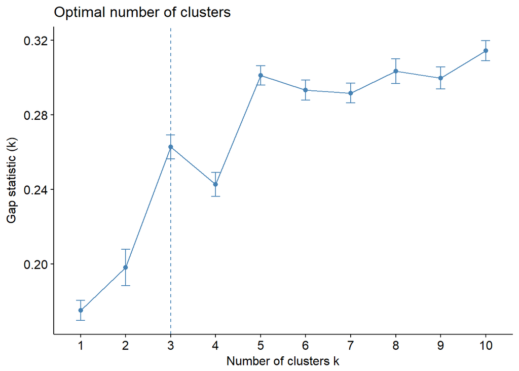

```r
week8 %>%
  select(starts_with("job"), salary, tenure, age) %>%
  scale() %>%
  na.omit() %>%
  fviz_nbclust(x = ., FUNcluster = kmeans, method = "gap")
```

We can see that 3 kmeans clusters works pretty well, but note that we would be very likely to get a different optimal value with something like silhouette.

We can also try the NbClust package (this will take a bit to run):

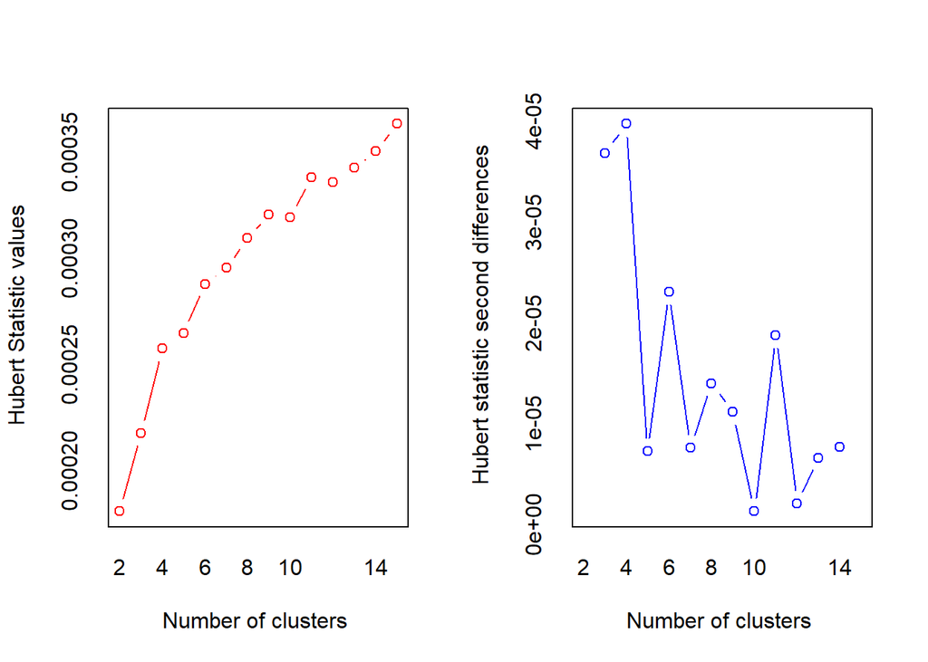

```
## *** : The Hubert index is a graphical method of determining the number of clusters.
##                 In the plot of Hubert index, we seek a significant knee that corresponds to a
##                 significant increase of the value of the measure i.e the significant peak in Hubert
##                 index second differences plot.
##
```

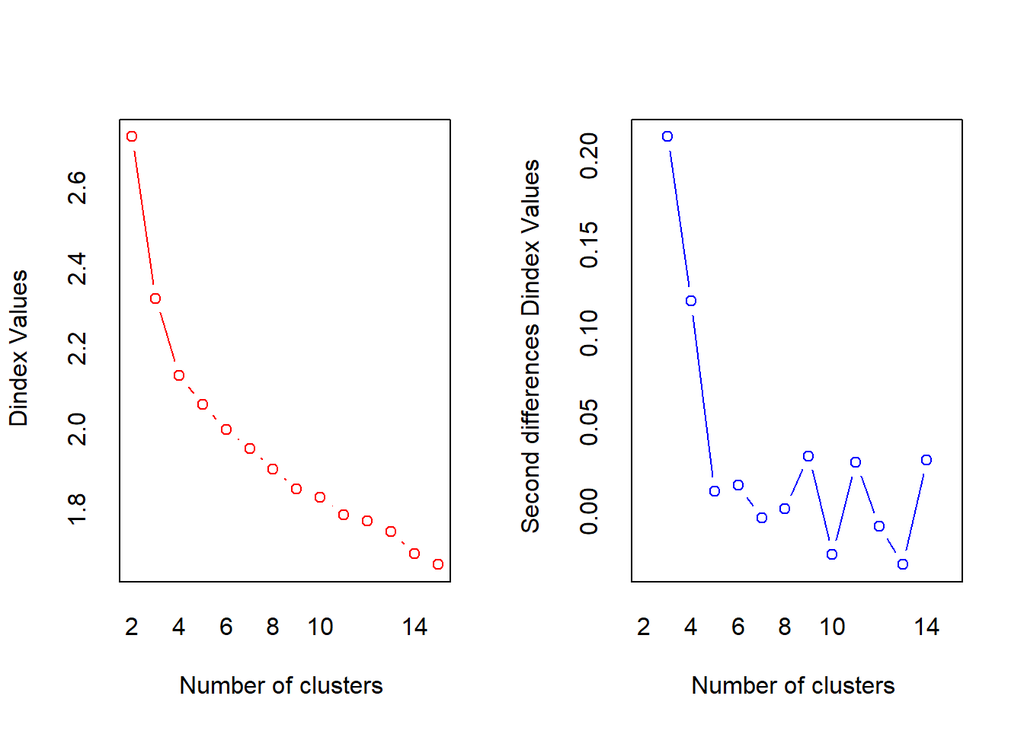

```
## *** : The D index is a graphical method of determining the number of clusters.
##                 In the plot of D index, we seek a significant knee (the significant peak in Dindex
##                 second differences plot) that corresponds to a significant increase of the value of
##                 the measure.
##
## * Among all indices:
## * 4 proposed 2 as the best number of clusters
## * 10 proposed 3 as the best number of clusters
## * 5 proposed 4 as the best number of clusters
## * 1 proposed 5 as the best number of clusters
## * 1 proposed 9 as the best number of clusters
## * 2 proposed 15 as the best number of clusters
##
##                    ***** Conclusion *****
##
## * According to the majority rule, the best number of clusters is  3
##
##
```

```r
nbTest = week8 %>%
  dplyr::select(starts_with("job"), salary, tenure, age) %>%
  scale() %>%
  na.omit() %>%
  NbClust::NbClust(data = ., distance = "euclidean", method = "kmeans")
```

Well if the majority rules…

For a first pass, let’s see what k-means might get us.

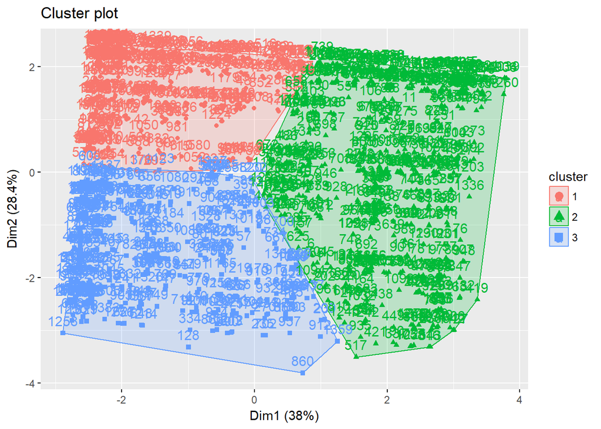

```r
clusterData = week8 %>%
  dplyr::select(id, starts_with("job"), salary, tenure, age)

kmeansTest = kmeans(x = scale(na.omit(clusterData[,-grepl("id",
                                                         names(clusterData))])),
                    centers = 3)

fviz_cluster(kmeansTest, scale(na.omit(clusterData[,-grepl("id",
                                                         names(clusterData))])))
```

That looks like it partioned pretty nicely. Now let’s look at our cluster centers:

Since we scaled our data, those center are a bit hard to interpret and they don’t represent real observations anyway.

```r
kmeansTest$centers
```

```
##   jobTasksSDSA jobBalanceSDSA jobPaySDSA jobRecognitionSDSA
## 1    0.7518947     0.83488231  0.7737307          0.7917864
## 2   -0.9703258     0.08712283 -0.9933999         -0.9887882
## 3    0.6666678    -0.97028424  0.6785296          0.6535394
##   jobAdvancementSDSA jobCoworkersSDSA jobManagementSDSA      salary
## 1          0.7686187        0.8291067         0.8390055  0.01451881
## 2         -0.9863675        0.1050965         0.1034364  0.03997819
## 3          0.6733577       -0.9908577        -0.9984062 -0.07336974
##        tenure         age
## 1  0.04530319  0.10760355
## 2  0.02279067 -0.06343602
## 3 -0.07918239 -0.01538391
```

Those centers are practically meaningless (we can understand magnitude and the sort). Maybe we should unscale them:

```r
usedData = clusterData %>%
  dplyr::select(-id) %>%
  na.omit() %>%
  scale()

kmeansCenters = as.data.frame(kmeansTest$centers)

varNames = names(kmeansCenters)

unscaleCenters = function(varName) {
  unscaled = kmeansCenters[, varName] *
    attr(x = usedData, which = "scaled:scale")[varName] +
    attr(x = usedData, which = "scaled:center")[varName]

  res = data.frame(unscaled)

  names(res) = varName

  return(res)
}

clusterCentersRaw = lapply(varNames, function(x) unscaleCenters(x)) %>%
  bind_cols(.)

clusterCentersRaw
```

```
##   jobTasksSDSA jobBalanceSDSA jobPaySDSA jobRecognitionSDSA
## 1     5.300000       5.647059   6.338235           6.388235
## 2     1.816162       4.153535   3.254545           3.260606
## 3     5.127596       2.041543   6.172107           6.145401
##   jobAdvancementSDSA jobCoworkersSDSA jobManagementSDSA   salary   tenure
## 1           6.361765         6.588235          6.597059 77282.98 5.117647
## 2           3.305051         5.355556          5.349495 78079.52 5.046465
## 3           6.195846         3.489614          3.480712 74533.24 4.724036
##        age
## 1 39.12353
## 2 37.39596
## 3 37.88131
```

We can certainly tell a story about these 3 clusters, but we will save that exercise for the next step.

Instead of k-means, let’s try a different clustering method: medioids. Partitioning around medioids (pam) will actually find the observation that rests in the middle of a cluster.

Just so that we get a sense of how it works, let’s go through the cluster number exercise again:

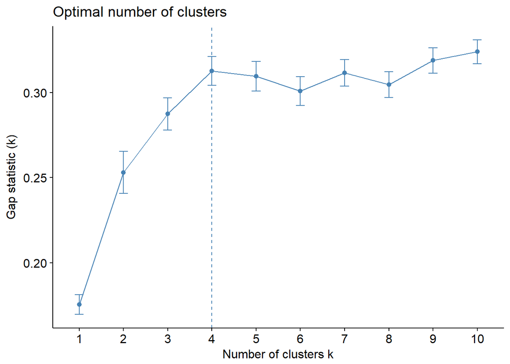

```r
week8 %>%
    dplyr::select(starts_with("job"), salary, tenure, age) %>%
    scale() %>%
    na.omit() %>%
    fviz_nbclust(x = ., FUNcluster = pam, method = "gap")
```

This produced some different results, with 4 clusters suggested.

Let’s take a peak at it:

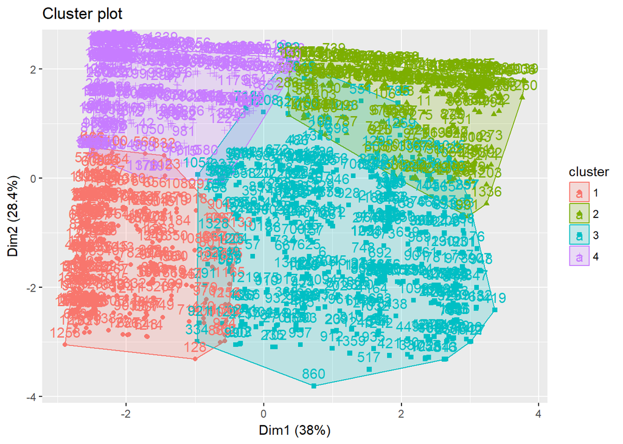

```r
pamTest = pam(x = scale(na.omit(clusterData[,-grepl("id",
                                                         names(clusterData))])),
                    k = 4)

fviz_cluster(pamTest, clusterData)
```

This one does not look as clean as our 3 cluster k-means, but let’s check out our mediods:

```r
pamTest$medoids
```

```
##      jobTasksSDSA jobBalanceSDSA jobPaySDSA jobRecognitionSDSA
## 595     1.0979367     -0.9910835  1.1529598          1.1400671
## 1358   -0.8794460      1.0115887 -1.1392690         -1.1371526
## 1372   -0.3851004     -0.4904155 -0.5662118         -0.5678476
## 1370    1.0979367      1.0115887  1.1529598          1.1400671
##      jobAdvancementSDSA jobCoworkersSDSA jobManagementSDSA      salary
## 595           1.1350560       -0.6910844        -1.2818362  0.14962490
## 1358         -1.1615096        1.0709553         1.0765814 -0.86643126
## 1372         -0.5873682       -0.6910844        -0.1026274  0.02353281
## 1370          0.5609146        1.0709553         1.0765814 -0.58014308
##           tenure        age
## 595  0.324360671 -0.4986618
## 1358 0.324360671 -0.2016442
## 1372 0.008095524  0.3923910
## 1370 0.008095524 -0.2016442
```

Scaled values!?! Those don’t really tell us too much. While our coding might have looked overly-complicated, it gives us the flexibility to use rows for pulling stuff out:

```r
clusterData[rownames(pamTest$medoids), ]
```

```
##         id jobTasksSDSA jobBalanceSDSA jobPaySDSA jobRecognitionSDSA
## 595  M579F            6              2          7                  7
## 1358 O343O            2              6          3                  3
## 1372 Y454F            3              3          4                  4
## 1370 Y322Y            6              6          7                  7
##      jobAdvancementSDSA jobCoworkersSDSA jobManagementSDSA salary tenure
## 595                   7                4                 3  81510      6
## 1358                  3                7                 7  49721      6
## 1372                  4                4                 5  77565      5
## 1370                  6                7                 7  58678      5
##      age
## 595   33
## 1358  36
## 1372  42
## 1370  36
```

Now we can tell a story about these clusters!

The person with id “M579F”, representing cluster 1, has high job satisfaction and lower interpersonal satisfaction, is well paid, and is not new at the organization.

Cluster 2 is *almost* the opposite of cluster 1. The medioid person, “O343O”, likes the people, hates the work, is making less money than the mean and median, and is slightly younger than the average employee.

Cluster 3 is likely the saltiest of the bunch, despite making around the average salary. They might be getting slightly bitter being around all of the younger folks.

We can also get some information about the clusters:

```r
pamTest$clusinfo
```

```
##      size max_diss  av_diss diameter separation
## [1,]  254 3.829990 2.235094 6.060854  0.7032616
## [2,]  253 4.528500 2.176290 6.257811  0.7369412
## [3,]  369 4.248754 2.516155 7.608756  0.7032616
## [4,]  296 4.322873 2.122393 5.904069  0.8574018
```

The split is not quite equal, but we don’t have anything that completely runs aways with people.

Let’s try one more thing on this front: clara. It is pam, but for large applications. It performs some sampling that makes it go much faster; you will notice the speed difference when we run our k check (we can even be pretty cool with bumping the iterations up to 500 for maximum stability).

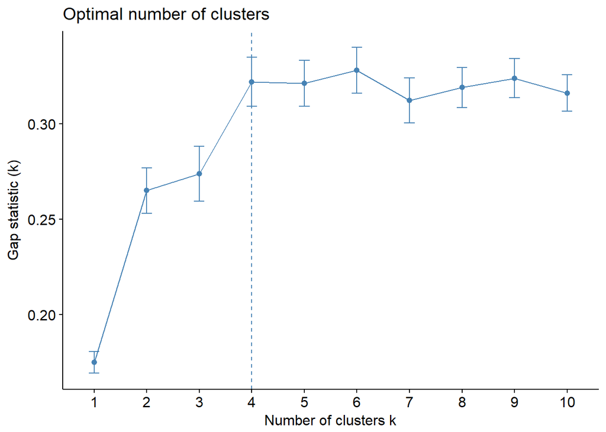

```r
week8 %>%
    dplyr::select(starts_with("job"), salary, tenure, age) %>%
    scale() %>%
    na.omit() %>%
    fviz_nbclust(x = ., FUNcluster = clara, method = "gap", nboot = 500)
```

It still pops up as 4, but we can be more confident. Let’s see how it fairs:

```r
claraTest = clara(x = scale(na.omit(clusterData[,-grepl("id",
                                                         names(clusterData))])),
                    k = 4)
```

```r
clusterData[rownames(claraTest$medoids), ]
```

```
##         id jobTasksSDSA jobBalanceSDSA jobPaySDSA jobRecognitionSDSA
## 163  T127O            5              3          7                  6
## 1316 G990Q            2              7          3                  4
## 213  Q718W            2              3          4                  4
## 759  V420S            5              5          6                  7
##      jobAdvancementSDSA jobCoworkersSDSA jobManagementSDSA salary tenure
## 163                   7                4                 4  51403      4
## 1316                  4                7                 7  50533      2
## 213                   3                5                 5  77845      8
## 759                   6                7                 6  52541      6
##      age
## 163   36
## 1316  36
## 213   38
## 759   39
```

While a very similar story appears within the medioids, it is a bit different.